# Venue Performance and Home-Court Advantage

Md Soad Solaiman

29 July 2025

# 1. Executive Summary

Netball is growing in France, and La Commission de Netball is a club there. It wants to understand how a professional competition there might work financially. Since Australia already runs a mature, professional women’s netball league, this report uses that data as a working model. Two questions guided the analysis. Does home-ground support give teams a real advantage? And does team performance affect venue income? Teams do tend to perform better at home. Income also relates more closely to team performance than to attendance alone.

# 2. Business Context

France does not yet have a professional netball league of its own. Its national team is still young and ranked outside the world’s top tier. Building a case for a French competition means learning from a league that already works. Super Netball in Australia offers that model. La Commission has access to several seasons of this data, covering results, attendance and total venue income. Some of it is real history. Some is synthetic, added for this exercise. Financial detail is limited, since real venue figures are commercially sensitive, so venue income is only available as one combined total.

# 3. Business Objectives

- Test whether teams win more, and score better, at home than away.
- Compare scoring and goal ratio across all eight teams.
- Build a season-level summary of each team’s income, points and home attendance.
- Check whether home attendance is linked to venue income.
- Check whether home attendance is linked to team performance.
- Check whether team performance is linked to income per spectator.

# 4. Dataset

The dataset covers eight teams: Fever, Firebirds, GIANTS, Lightning, Magpies, Swifts, Thunderbirds and Vixens. Source fields cover team name, state, season-level venue income, and 14 round-level match records. Each round record combines venue status, team score, opponent score and attendance in a single text field.

Source data preview before cleaning

Team Names

STATE

COLLECTED

RND 01

RND 02

RND 03

RND 04

RND 05

RND 06

RND 07

RND 08

RND 09

RND 10

RND 11

RND 12

RND 13

RND 14

Swifts

NSW

$1,302,202.59

away, 53 for, 58 against, 3331 attended

home, 54 for, 44 against, 4938 attended

away, 59 for, 59 against, 3345 attended

away, 53 for, 62 against, 5260 attended

away, 45 for, 50 against, 3183 attended

home, 54 for, 55 against, 5179 attended

home, 56 for, 59 against, 4666 attended

home, 50 for, 55 against, 4201 attended

home, 54 for, 62 against, 3783 attended

away, 51 for, 48 against, 4763 attended

home, 50 for, 48 against, 3453 attended

away, 50 for, 62 against, 5879 attended

away, 49 for, 63 against, 5263 attended

home, 48 for, 67 against, 3633 attended

essayer

Vixens

VIC

$2,765,922.37

home, 58 for, 55 against, 3088 attended

away, 52 for, 58 against, 3425 attended

home, 59 for, 59 against, 3345 attended

home, 56 for, 45 against, 3349 attended

away, 66 for, 50 against, 5775 attended

home, 59 for, 51 against, 3767 attended

away, 60 for, 56 against, 5852 attended

away, 75 for, 54 against, 5379 attended

away, 62 for, 54 against, 3783 attended

home, 70 for, 59 against, 4366 attended

home, 66 for, 55 against, 4804 attended

away, 52 for, 56 against, 4411 attended

home, 71 for, 50 against, 5167 attended

away, 68 for, 42 against, 2606 attended

The raw source contains 10 rows and 17 columns before cleaning.

# 5. Data Preparation

## 5.1 Data quality assessment and cleaning

The source contains a duplicated team record, a non-data row, and three malformed match values. Matching each value against its corresponding opponent record restores attendance figures of 5,397 and 3,665, and an opponent score of 49. Currency formatting is removed from the income field, and the cleaned teams are ordered by state.

Cleaning leaves 8 team records, one per team, after removing the duplicate, the non-data row, and correcting the three malformed values.

## 5.2 Reshaping and variable preparation

Round columns are reshaped into one record per team and round. Regular-expression extraction then separates each record into venue status, team score, opponent score and attendance. Variable names and data types are standardised last.

Reshaping produces 112 round-level match records. A completeness check confirms the extracted fields before modelling.

Missing-value check after reshaping

| col_name | cnt | pcnt |
| --- | --- | --- |
| team_names | 0 | 0 |
| row_id_t | 0 | 0 |
| state | 0 | 0 |
| collected | 0 | 0 |
| rnd | 0 | 0 |
| at_home | 0 | 0 |
| score | 0 | 0 |
| against | 0 | 0 |
| attendance | 0 | 0 |

## 5.3 Feature engineering

Three performance variables are derived here. Each match is classified as a win, a tie, or a loss. Competition points follow directly: 4 for a win, 2 for a tie, 0 for a loss. Goal ratio is team score divided by opponent score.

Analysis-ready match records (sample)

| team_names | collected | rnd | at_home | score | attendance | result | points | goal_ratio |
| --- | --- | --- | --- | --- | --- | --- | --- | --- |
| Swifts | 1302202.6 | 1 | away | 53 | 3331 | loss | 0 | 0.91 |
| GIANTS | 2711504.0 | 1 | home | 58 | 3331 | win | 4 | 1.09 |
| Lightning | 2944273.8 | 1 | away | 56 | 5703 | tie | 2 | 1.00 |
| Firebirds | 1923216.2 | 1 | home | 56 | 5703 | tie | 2 | 1.00 |
| Thunderbirds | 694319.7 | 1 | home | 56 | 6548 | win | 4 | 1.10 |

The analysis-ready dataset holds 112 round-level records across 8 teams.

# 6. Exploratory Data Analysis

## 6.1 Team performance distributions

Score distributions show that some teams scored consistently higher, while others varied more widely from match to match. Goal ratio brings the opponent’s performance into the comparison directly: a high score can still produce a lower ratio when the opponent also scores strongly.

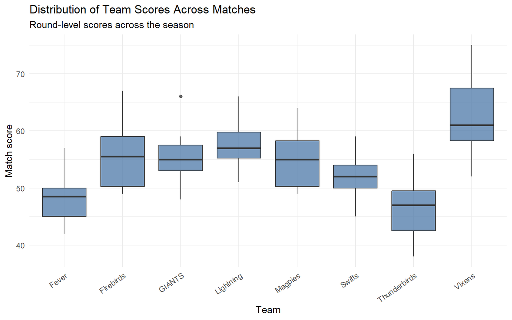

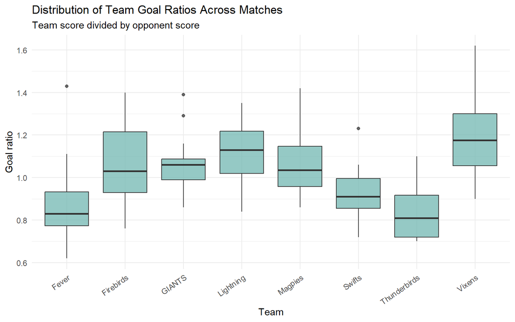

# 7. Statistical Analysis

## 7.1 Home-court performance

Teams recorded 28 wins at home compared with 26 wins away. The median goal ratio is also higher for home matches. Together, these descriptive patterns point to a home-court advantage in this dataset.

Match wins by home and away status

| at_home | n |
| --- | --- |
| home | 28 |
| away | 26 |

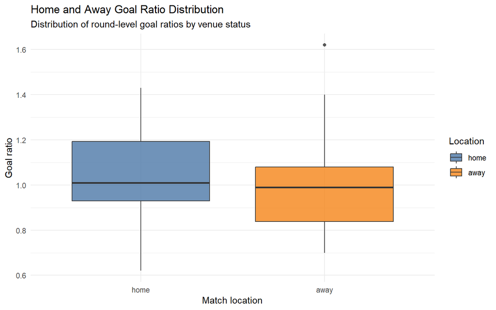

## 7.2 Venue income summary

Season-level venue income is combined here with total competition points and cumulative home attendance. Income per spectator is total collected income divided by total home attendance.

Team performance, home attendance and venue income summary

| team_names | collected | final_points | total_home_crowd | inc_per_spec |
| --- | --- | --- | --- | --- |
| Fever | 628933.0 | 8 | 22269 | 28.24 |
| Firebirds | 1923216.2 | 30 | 37394 | 51.43 |
| GIANTS | 2711504.0 | 40 | 29508 | 91.89 |
| Lightning | 2944273.8 | 46 | 29019 | 101.46 |
| Magpies | 2275873.8 | 36 | 40672 | 55.96 |
| Swifts | 1302202.6 | 14 | 29853 | 43.62 |
| Thunderbirds | 694319.7 | 4 | 37850 | 18.34 |
| Vixens | 2765922.4 | 46 | 27886 | 99.19 |

## 7.3 Attendance, performance and income relationships

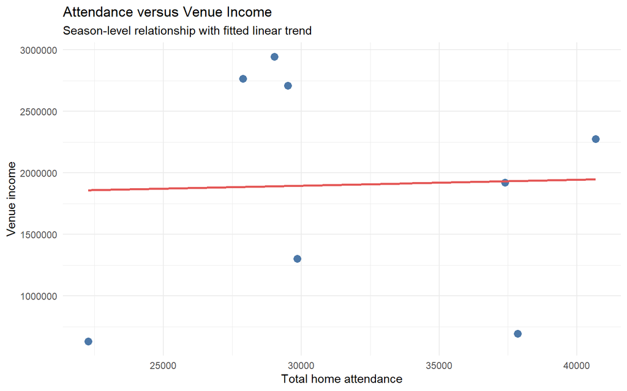

Venue income rises only marginally with crowd size, and the observations are widely dispersed. This is a weak positive relationship. Other revenue components, such as pricing or non-attendance income, may matter more than crowd size alone.

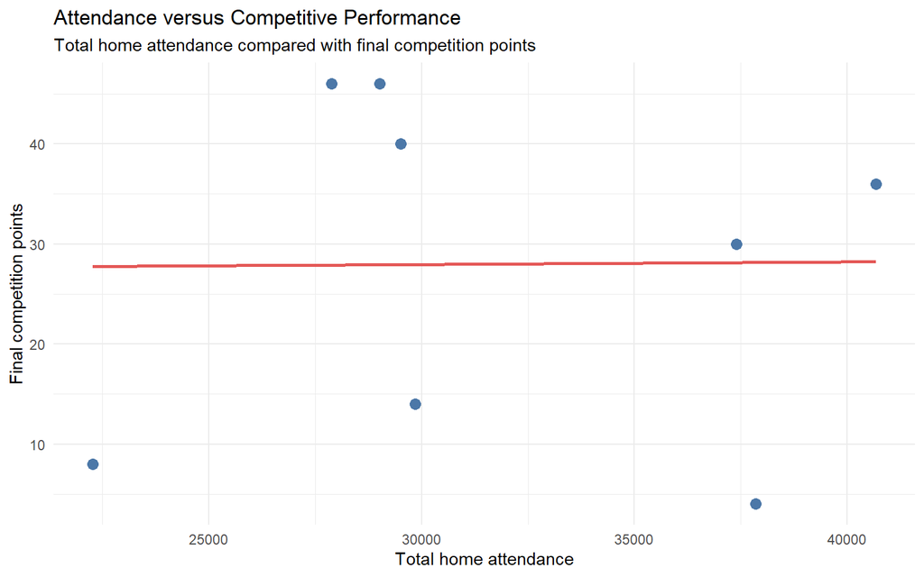

The fitted line here is close to flat, and the observations are dispersed. No clear relationship is evident between home crowd size and final competition points.

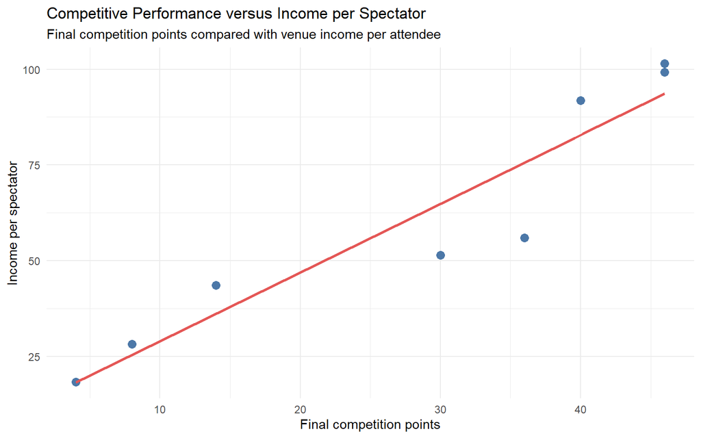

This relationship is the clearest of the three. Teams with stronger competitive performance also generated more income per attendee in this dataset.

# 8. Results

This analysis produces four principal results:

- Home teams recorded more wins than away teams (28 versus 26).
- The median goal ratio was higher for home matches.
- Home attendance had a weak relationship with venue income, and no clear relationship with competition points.
- Competition points had a strong relationship with income per spectator.

# 9. Conclusion

# 10. Limitations

- The analysis covers a small number of teams from one season-level dataset.
- Venue income combines several revenue sources and does not include expenses.
- The fitted lines are exploratory visual summaries. No formal hypothesis tests or causal models were estimated.

# 11. Technical Appendix

## 11.1 Variable Definitions

- `team_names`: team identifier.
- `collected`: total season-level income collected by the home venue.
- `rnd`: match round.
- `at_home`: home or away match status.
- `score`: goals scored by the team.
- `attendance`: match attendance.
- `result`: derived win, tie, or loss.
- `points`: derived competition points.
- `goal_ratio`: team score divided by opponent score.
- `final_points`: total competition points by team.
- `total_home_crowd`: cumulative attendance at home matches.
- `inc_per_spec`: collected income divided by total home attendance.

## 11.2 Reproducibility

This report uses `tidyverse` for data import, cleaning, reshaping, feature engineering, aggregation and plotting. `inspectdf` supports the missing-value inspection. All file references are relative to the project structure.